# finalized analysis of EPEC data

```r
knitr::opts_chunk$set(echo = TRUE)
knitr::opts_chunk$set(include = TRUE)
knitr::opts_chunk$set(fig.width = 6)
knitr::opts_chunk$set(fig.height = 5)
library(greekLetters)
library(RUVSeq)
library(EDASeq)
library(DESeq2)
library(PCAtools)
library('org.Hs.eg.db')
library(EGSEA)
library(limma)
library(pheatmap)
library(eulerr)
library(UpSetR)
library(clusterProfiler)
library(tidyverse)
library(ggprism)
library(rcartocolor)
library(patchwork)
```

Define all helper functions and color choices

```r
theme_set(theme_prism(base_size = 14) + theme(legend.title = element_text()))
#Set color choices from CARTOcolors
discrete_pal_choice <- "Bold"
cont_pal_choice <- "BluYl"
diverg_pal_choice <- "Geyser"
#Set color vectors
cont_colors <- carto_pal(name = cont_pal_choice)
chosen_cont_colors <- cont_colors [c(2,4,6,7)]
#Helper functions
calc_relative <- function(x) x/sum(x) * 100
#Set up paths for data, and results
data_path <- "short_infection_EPEC_reads/data/"
res_path <- "short_infection_EPEC_reads/results/"
```

#Read in the count data and rename the columns to fit the sample names

```r
counts <- read.table(here::here(str_c(data_path,"STAR_EPEC_reads_updated.txt")),header = F, sep = "\t", stringsAsFactors = F)
#Next manipulate the table to remove redundant columns and only keep relevant columns (1 columns with gene names, and the rest with counts for reverse stranded library
counts_simple <- counts [,seq(from=4,to=96,by=4)]
colnames(counts_simple) <- c("4UIN", "4UIWT", "490WT", "490N", "4180N", "4180WT", "5UIN", "5UIWT", "545WT", "545N", "590WT", "590N", "5180N", "5180WT", "6UIN", "6UIWT", "645WT", "645N", "690WT", "690N", "6180N", "6180WT", "445N", "445WT")
counts_simple <- counts_simple %>%
  dplyr::select(-`6UIN`)
counts_simple$Gene_ID <- counts$V1

filter <- apply(dplyr::select(counts_simple,-Gene_ID),1,function(x) mean(x)>5)
counts_simple <- counts_simple [filter,] %>%
  mutate(Gene_ID = str_remove(Gene_ID, "(gene:)|(transcript:)"))

#write.table(counts_simple,file=here::here(str_c(res_path,"tables/only_reverse_strand_counts_cleaned.txt")),sep = "\t", row.names = F)
```

Visualize EscN counts per sample: The EscN gene is: E2348C_3948

```r
escn_counts <- counts_simple %>%
  filter(Gene_ID == "E2348C_3948") %>%
  pivot_longer(-Gene_ID, names_to = "samples", values_to = "numbers") %>%
  mutate(time = if_else(str_detect(samples,"UI"),
                        0,
                        as.numeric(str_remove(str_extract(samples, "[:digit:]+"), "^[:digit:]"))),
         strain = if_else(str_detect(samples,"WT"), str_c("bold(WT)"),str_c("bold(Delta)*bold(EscN)"))) %>%
  ggplot() +
  geom_point(aes(x=fct_reorder(samples,time), y = numbers), size = 3) +
  labs(y = "counts", title = "counts for EscN gene", x = element_blank()) +
  facet_wrap(~strain, ncol = 1, scales = "free", labeller = label_parsed) +
  theme(axis.text.x = element_text(angle = 75, vjust = 0.6))
escn_counts_toscale <- escn_counts + facet_wrap(~strain, scales = "free_x" ,ncol = 1, labeller = label_parsed)

#ggsave(here::here(str_c(res_path,"raw counts for escN.png")),plot = escn_counts,width = 6, height = 8, dpi = 1080)
#ggsave(here::here(str_c(res_path,"raw counts for escN_toscale.png")),plot = escn_counts_toscale, width = 6, height = 8, dpi = 1080)
```

Visualize mapping stats

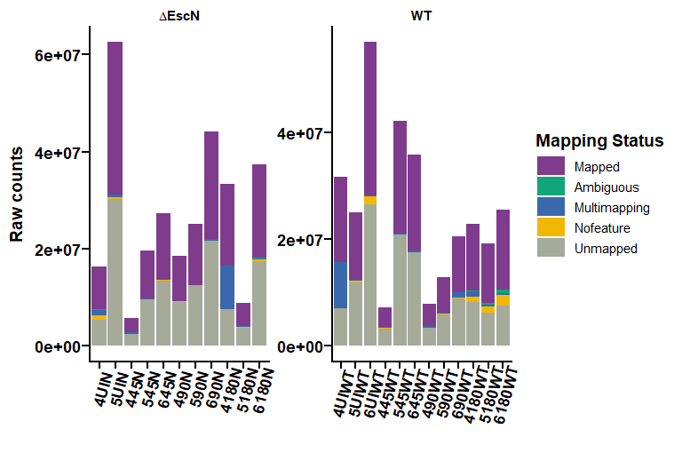

```r
#Visualize alignment statistics
counts_stats <- counts_simple %>%
  dplyr::slice(1:4) %>%
  pivot_longer(-Gene_ID, values_to = "numbers", names_to = "mapping")
mapped <-  counts_simple %>%
  select(-Gene_ID) %>%
  summarise(across(everything(), sum)) %>%
  pivot_longer(everything(),values_to = "numbers", names_to = "mapping") %>%
  mutate(Gene_ID = "Mapped") %>%
  bind_rows(counts_stats) %>%
  group_by(mapping) %>%
  mutate(rel_numbers = calc_relative(numbers)) %>%
  mutate(Gene_ID = fct_relevel(str_to_title(str_replace(Gene_ID, "N_","")), "Mapped")) %>%
  mutate(time = if_else(str_detect(mapping,"UI"),
                        0,
                        as.numeric(str_remove(str_extract(mapping, "[:digit:]+"), "^[:digit:]"))),
         strain = if_else(str_detect(mapping,"WT"), str_c("bold(WT)"),str_c("bold(Delta)*bold(EscN)")))

#Raw counts stats
raw_count_plot <- ggplot(mapped, aes(x=fct_reorder(mapping,time), y=numbers, fill = Gene_ID)) +
  geom_bar(stat = "identity") + scale_fill_carto_d(palette = discrete_pal_choice) +
  labs(x = "", y = "Raw counts") +
  theme(axis.text.x = element_text(angle = 75, vjust = 0.75, hjust = 0.6)) +
  guides(fill = guide_legend(title = "Mapping Status")) +
  facet_wrap(~strain, scales = "free", labeller = label_parsed)
#Relative count stats
rel_count_plot <- ggplot(mapped, aes(x=fct_reorder(mapping,time), y=rel_numbers, fill = Gene_ID)) +
  geom_bar(stat = "identity") + scale_fill_carto_d(palette = discrete_pal_choice) +
  labs(x = "", y = "Proportion of counts") +
  theme(axis.text.x = element_text(angle = 75, vjust = 0.75, hjust = 0.6),
        legend.title = element_text()) +
  guides(fill = guide_legend(title = "Mapping Status")) +
  facet_wrap(~strain, scales = "free", labeller = label_parsed)

#pdf(file = here::here(str_c(res_path,"mapping stats.pdf")), width = 8, height = 5.5)
raw_count_plot
```

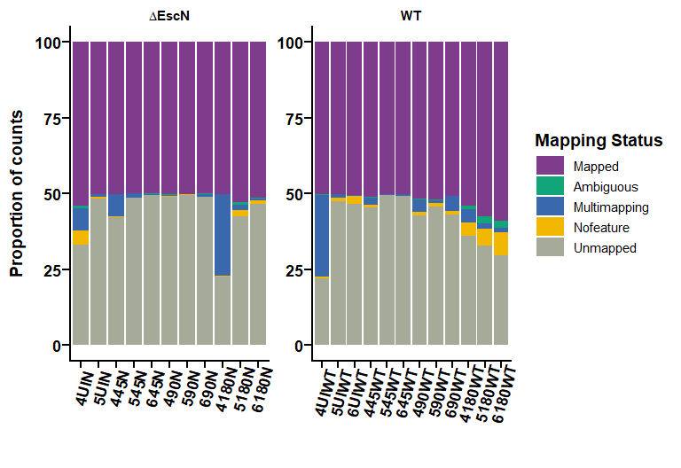

```r
rel_count_plot
```

```r
#dev.off()
```

Calculate statistics of types of transcripts mapped

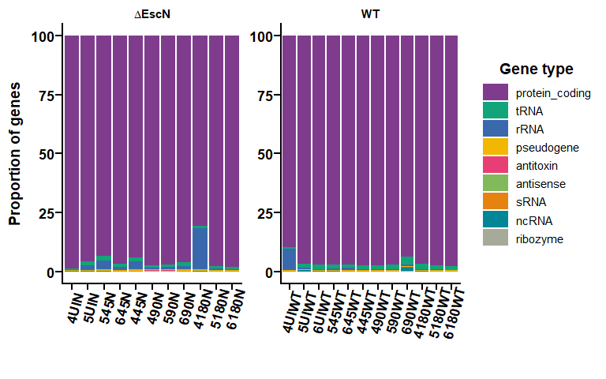

```r
#Prepare gene annotation from the gff3 file
geneids <- read_delim(here::here(str_c(data_path,"EPEC_annot.rel-41.gff3")),
       delim = "\t", escape_double = FALSE,
       col_names = FALSE, trim_ws = TRUE, skip = 11)
annot <- geneids %>%
  filter(X3 == "gene" | X3 == "pseudogene" | X3 == "rRNA_gene" |
           X3 == "tRNA_gene" | X3 == "ncRNA_gene") %>%
  filter(str_detect(X9,"ID=gene")) %>%
  select(X9) %>%
  separate(X9, into = c("ID", "Name", "Biotype", "Description", "Geneid"), extra = "drop", sep = ";") %>%
  mutate(ID = str_remove(ID, "ID=gene:"),
         true_name = case_when(
           str_detect(Name, "Name") ~ str_remove(Name, "Name="),
           str_detect(Name, "biotype") ~ ID
           ), true_biotype = case_when(
             str_detect(Name, "biotype") ~ str_remove(Name, "biotype="),
             str_detect(Biotype, "biotype") ~ str_remove(Biotype, "biotype=")
           )) %>%
  mutate(true_name = if_else(duplicated(true_name), ID, true_name))
c_type <- counts_simple %>%
  dplyr::slice(-1:-4) %>%
  left_join(dplyr::select(annot, ID, true_biotype), by = c("Gene_ID" = "ID")) %>%
  dplyr::select(-Gene_ID) %>%
  rename_with(function(x) "Type",last_col()) %>%
  group_by(Type) %>%
  summarise(across(everything(),sum)) %>%
  reshape2::melt() %>%
  group_by(variable) %>%
  mutate(rel_numbers = calc_relative(value)) %>%
  mutate(time = if_else(str_detect(variable,"UI"),
                        0,
                        as.numeric(str_remove(str_extract(variable, "[:digit:]+"), "^[:digit:]"))),
         strain = if_else(str_detect(variable,"WT"), str_c("bold(WT)"),str_c("bold(Delta)*bold(EscN)")))
c_type_no_mrna <- c_type %>%
  filter(Type != "protein_coding") %>%
   group_by(variable) %>%
  mutate(rel_numbers = calc_relative(value))

rel_type_plot <- ggplot(c_type, aes(x=fct_reorder(variable,time), y=rel_numbers, fill = fct_reorder(Type,rel_numbers, .desc = T))) +
  geom_bar(stat = "identity") + scale_fill_carto_d(palette = discrete_pal_choice) +
  labs(x = "", y = "Proportion of genes", fill = "Gene type") +
  theme(axis.text.x = element_text(angle = 75, vjust = 0.75, hjust = 0.6)) +
  facet_wrap(~strain, scales = "free", labeller = label_parsed)
rel_type_plot_no_mrna <- ggplot(c_type_no_mrna,
                                aes(x=fct_reorder(variable,time), y=rel_numbers, fill = fct_reorder(Type,rel_numbers, .desc = T))) +
  geom_bar(stat = "identity") + scale_fill_carto_d(palette = discrete_pal_choice) +
  labs(x = "", y = "Proportion of genes", fill = "Gene type") +
  theme(axis.text.x = element_text(angle = 75, vjust = 0.75, hjust = 0.6)) +
  facet_wrap(~strain, scales = "free", labeller = label_parsed)
#pdf(file = here::here(str_c(res_path,"mapping stats by gene type.pdf")), width = 8, height = 5)
rel_type_plot
```

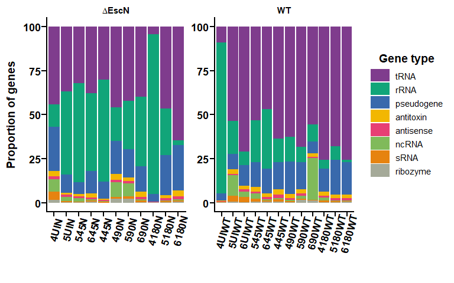

```r
rel_type_plot_no_mrna
```

```r
#dev.off()
```

Apply EDAseq normalization to the data

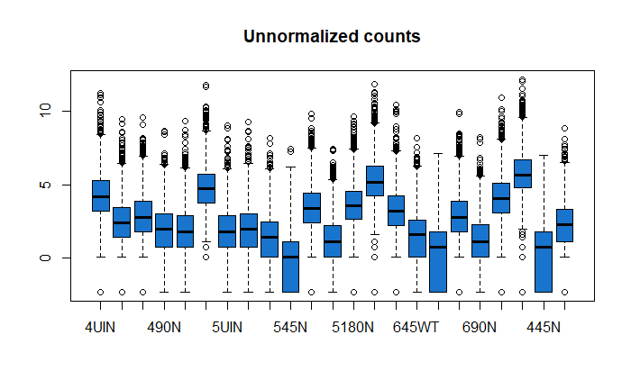

```r
#Use EDAseq to normalize the libraries
c_mat <- counts_simple %>%
                     dplyr::select(-dplyr::last_col()) %>%
                     dplyr::slice(-1:-4) %>%
                     as.matrix()
rownames(c_mat) <- counts_simple$Gene_ID [-1:-4]
pData <- data.frame(genotype=vector(mode = "logical", length = ncol(c_mat)),
                    timepoint = vector(mode = "logical", length = ncol(c_mat)),
                    samples = colnames(c_mat),
                    row.names = colnames(c_mat))
#Here we are setting all uninfected samples as WT to pool 0hr timepoints
pData <- pData %>%
  mutate(genotype = case_when(
    str_detect(samples, "WT") ~ "WT",
    str_detect(samples, "N") ~ "N"
  ), timepoint = if_else(str_detect(samples,"UI"),
                        0,
                        as.numeric(str_remove(str_extract(samples, "[:digit:]+"), "^[:digit:]")))) %>%
  dplyr::select(-samples)

data <- newSeqExpressionSet(counts=c_mat,
                            phenoData=pData)
#Normalize the data next
dataNorm <- betweenLaneNormalization(data, which="full")
#Plot the counts
#pdf(here::here(str_c(res_path,"Normalization effect on the library.pdf")), width = 8, height = 6.3)
boxplot(data, main = "Unnormalized counts", col = "dodgerblue3")
```

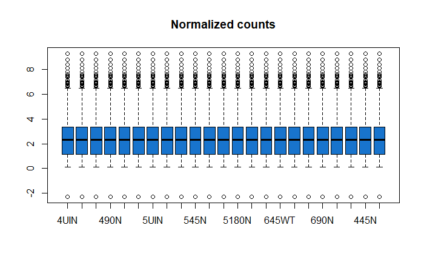

```r
boxplot(dataNorm, main = "Normalized counts", col = "dodgerblue3")
```

```r
#dev.off()
#For DE we will create this analysis with offset values
dataOffset <- betweenLaneNormalization(data,
                                       which="full",offset=TRUE)
```

Next step is to use normalized counts in the DESEq2 analysis of differential expression

[figure not shown]

Identify differentially expressed genes

```r
res45 <- results(dds, contrast = c("group","WT45", "WT0"))
res90 <- results(dds, contrast = c("group","WT90", "WT0"))
res180 <- results(dds, contrast = c("group","WT180", "WT0"))
time_res <- list(res45,res90,res180) %>%
  map(as.data.frame) %>%
  map2(c(".45",".90",".180"), ~rename_with(.x, .fn = function(colname) str_c(colname,.y))) %>%
  map(rownames_to_column, var = "geneid") %>%
  reduce(left_join)
time_res_annot <- time_res %>%
  left_join(dplyr::select(annot,ID,true_name,true_biotype), by = c("geneid" = "ID"))
#write.table(time_res_annot, here::here(str_c(res_path, "tables/EDAseq_normalized results comparing by time WT infection.csv")),
 #          sep = ",", row.names = F)

res45vsn <- results(dds, contrast = c("group","WT45", "N45"))
res90vsn <- results(dds, contrast = c("group","WT90", "N90"))
res180vsn <- results(dds, contrast = c("group","WT180", "N180")) #Some significant differences shown
time_resvsn_annot <- list(res45vsn,res90vsn,res180vsn) %>%
  map(as.data.frame) %>%
  map2(c(".45",".90",".180"), ~rename_with(.x, .fn = function(colname) str_c(colname,.y))) %>%
  map(rownames_to_column, var = "geneid") %>%
  reduce(left_join) %>%
  left_join(dplyr::select(annot, ID, true_name, true_biotype), by = c("geneid" = "ID"))
#write.table(time_resvsn_annot, here::here(str_c(res_path, "tables/EDAseq_normalized results comparing  WT and EscN infection.csv")),
 #          sep = ",", row.names = F)
```

Interestingly, bfp genes are down-regulated during infection when T3SS is present, let’s plot that

```r
svg(here::here(str_c(res_path,"bfp operon differences.svg")), width = 7, height = 5)
pheatmap(bfp_z_scaled [,c(sample_order_n, sample_order_wt)],
         annotation_col=df, annotation_row = df_row, annotation_names_row = F,
         annotation_colors = list("Strain" = c("WT" =carto_pal(12,discrete_pal_choice) [2],
                                                         "Mutant" = carto_pal(12,discrete_pal_choice) [1]),
                                  "Time of Infection (min)" = c("0" = chosen_cont_colors [1],
                                                  "45" = chosen_cont_colors [2],
                                                  "90" = chosen_cont_colors [3],
                                                  "180" = chosen_cont_colors [4]),
                                  "Locus" = c("bfp" = carto_pal(12,"Safe") [1],
                                              "per" = carto_pal(12,"Safe") [2])),
         fontsize = 14, treeheight_row = 0, treeheight_col = 0, breaks = mybreaks,
         show_rownames = T, show_colnames = F, border_color = NA, fontsize_row = 14,
         gaps_row = 14, legend = F, annotation_names_col = F,
         color = color_scheme, cluster_rows = F, cluster_cols = F)
dev.off()
```

```r
pheatmap(bfp_z_scaled [,c(sample_order_n, sample_order_wt)],
         annotation_col=df, annotation_row = df_row, annotation_names_row = F,
         annotation_colors = list("Strain" = c("WT" =carto_pal(12,discrete_pal_choice) [2],
                                                         "Mutant" = carto_pal(12,discrete_pal_choice) [1]),
                                  "Time of Infection (min)" = c("0" = chosen_cont_colors [1],
                                                  "45" = chosen_cont_colors [2],
                                                  "90" = chosen_cont_colors [3],
                                                  "180" = chosen_cont_colors [4]),
                                  "Locus" = c("bfp" = carto_pal(12,"Safe") [1],
                                              "per" = carto_pal(12,"Safe") [2])),
         fontsize = 14, treeheight_row = 0, treeheight_col = 0, breaks = mybreaks,
         show_rownames = T, show_colnames = F, border_color = NA, fontsize_row = 14,
         gaps_row = 14, legend = F, annotation_names_col = F,
         color = color_scheme, cluster_rows = F, cluster_cols = F,
         width = 7, height = 5,
         filename = here::here(str_c(res_path,"bfp operon differences.png")))
```

Check overlap of DE genes between induced by time and by working T3SS

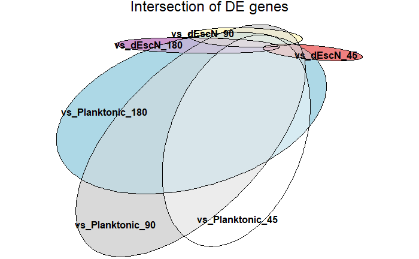

```r
#Create a list of DE genes for each comparison
per_time_de <- list(res45,res90,res180, res45vsn, res90vsn, res180vsn) %>%
  set_names(str_c("vs", rep(c("Planktonic","dEscN"), each = 3), rep(c(45,90,180), times = 2), sep = "_")) %>%
  map(as.data.frame) %>%
  map(~filter(.x, abs(log2FoldChange) >= 0.5, padj < 0.05)) %>%
  map(rownames_to_column, var = "geneid") %>%
  map(left_join, dplyr::select(annot, ID, true_name, true_biotype), by = c("geneid" = "ID")) %>%
  map(pull, true_name)
#Create a list of DE genes that were significant at any point either against time or
general_de <- list(reduce(per_time_de [c(1:3)], union), reduce(per_time_de [c(4:6)], union)) %>%
  set_names(c("vs Time","vs dEscN"))
#Create and plot euler fits for these genes
per_time_de_fit <- euler(per_time_de, shape = "ellipse")
general_de_fit <- euler(general_de, shape = "circle")

#pdf(here::here(str_c(res_path, "Euler of DE genes between comparisons.pdf")), width = 8, height = 6)
plot(per_time_de_fit, main = "Intersection of DE genes")
```

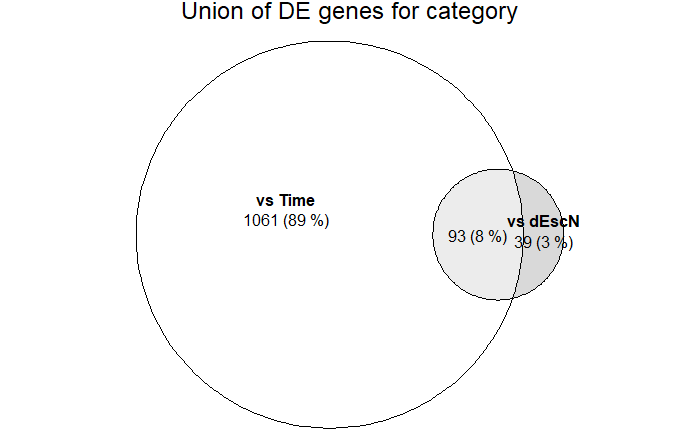

```r
plot(general_de_fit, quantities = list(type = c("counts","percent")), main = "Union of DE genes for category")
```